# House Price Classification

Antonny Mendonça, Júlia Sbardelatti, Rafael Monteiro, Wellington Santos

25 de Abril de 2021

# Introdução

O conjunto de dados deste projeto prova que muito mais influencia as negociações de preços do que o número de quartos ou uma cerca branca.

Com 79 variáveis explicativas que descrevem (quase) todos os aspectos das casas residenciais em Ames, Iowa, este projeto cria um algoritmo para predição do preço final de imóveis.

## Objetivo

O objetivo desse projeto é prever se o preço de um ímovel será Low, Mid ou High price.

## Avaliação

Para cada ID no conjunto de teste, você deve prever a classe da variável SalePrice

#### Métrica

- F1 Score

# Análise Inicial

```r
library(caret)
library(dplyr)
library(ggplot2)
library(ggthemes)
library(naniar)
library(mice)
library(randomForest)
library(knitr)
library(kableExtra)
```

## Configuração do Script

Depois definimos as configurações que serão utilizadas ao longo da seção. Neste caso, apenas definimos o tema padrão dos gráficos.

```r
theme_set(theme_bw())
```

## Visão Geral dos Dados

DDepois carregamos tanto os dados de treino e checamos a estrutura do dataframe carregado.

```r
train.data <- read.csv('train.csv')

kable(train.data[1:6,], "html") %>% kable_styling("striped") %>% scroll_box(width = "100%")
```

| Id | MSSubClass | MSZoning | LotFrontage | LotArea | Street | Alley | LotShape | LandContour | Utilities | LotConfig | LandSlope | Neighborhood | Condition1 | Condition2 | BldgType | HouseStyle | OverallQual | OverallCond | YearBuilt | YearRemodAdd | RoofStyle | RoofMatl | Exterior1st | Exterior2nd | MasVnrType | MasVnrArea | ExterQual | ExterCond | Foundation | … |
| --- | --- | --- | --- | --- | --- | --- | --- | --- | --- | --- | --- | --- | --- | --- | --- | --- | --- | --- | --- | --- | --- | --- | --- | --- | --- | --- | --- | --- | --- | --- |
| 2 | 20 | RL | 80 | 9600 | Pave |  | Reg | Lvl | AllPub | FR2 | Gtl | Veenker | Feedr | Norm | 1Fam | 1Story | 6 | 8 | 1976 | 1976 | Gable | CompShg | MetalSd | MetalSd | None | 0 | TA | TA | CBlock | … |
| 4 | 70 | RL | 60 | 9550 | Pave |  | IR1 | Lvl | AllPub | Corner | Gtl | Crawfor | Norm | Norm | 1Fam | 2Story | 7 | 5 | 1915 | 1970 | Gable | CompShg | Wd Sdng | Wd Shng | None | 0 | TA | TA | BrkTil | … |
| 6 | 50 | RL | 85 | 14115 | Pave |  | IR1 | Lvl | AllPub | Inside | Gtl | Mitchel | Norm | Norm | 1Fam | 1.5Fin | 5 | 5 | 1993 | 1995 | Gable | CompShg | VinylSd | VinylSd | None | 0 | TA | TA | Wood | … |
| 7 | 20 | RL | 75 | 10084 | Pave |  | Reg | Lvl | AllPub | Inside | Gtl | Somerst | Norm | Norm | 1Fam | 1Story | 8 | 5 | 2004 | 2005 | Gable | CompShg | VinylSd | VinylSd | Stone | 186 | Gd | TA | PConc | … |
| 8 | 60 | RL | NA | 10382 | Pave |  | IR1 | Lvl | AllPub | Corner | Gtl | NWAmes | PosN | Norm | 1Fam | 2Story | 7 | 6 | 1973 | 1973 | Gable | CompShg | HdBoard | HdBoard | Stone | 240 | TA | TA | CBlock | … |
| 9 | 50 | RM | 51 | 6120 | Pave |  | Reg | Lvl | AllPub | Inside | Gtl | OldTown | Artery | Norm | 1Fam | 1.5Fin | 7 | 5 | 1931 | 1950 | Gable | CompShg | BrkFace | Wd Shng | None | 0 | TA | TA | BrkTil | … |

```r
str(train.data)
```

```
## 'data.frame':    1148 obs. of  81 variables:
##  $ Id           : int  2 4 6 7 8 9 10 11 12 13 ...
##  $ MSSubClass   : int  20 70 50 20 60 50 190 20 60 20 ...
##  $ MSZoning     : chr  "RL" "RL" "RL" "RL" ...
##  $ LotFrontage  : num  80 60 85 75 NA 51 50 70 85 NA ...
##  $ LotArea      : int  9600 9550 14115 10084 10382 6120 7420 11200 11924 12968 ...
##  $ Street       : chr  "Pave" "Pave" "Pave" "Pave" ...
##  $ Alley        : chr  "" "" "" "" ...
##  $ LotShape     : chr  "Reg" "IR1" "IR1" "Reg" ...
##  $ LandContour  : chr  "Lvl" "Lvl" "Lvl" "Lvl" ...
##  $ Utilities    : chr  "AllPub" "AllPub" "AllPub" "AllPub" ...
##  $ LotConfig    : chr  "FR2" "Corner" "Inside" "Inside" ...
##  $ LandSlope    : chr  "Gtl" "Gtl" "Gtl" "Gtl" ...
##  $ Neighborhood : chr  "Veenker" "Crawfor" "Mitchel" "Somerst" ...
##  $ Condition1   : chr  "Feedr" "Norm" "Norm" "Norm" ...
```

[output cut: 67 more lines]

```r
any(is.na(train.data))
```

```
## [1] TRUE
```

```r
prop_miss(train.data)
```

```
## [1] 0.002968125
```

Também vamos sumarizar quais features possuem dados faltantes e em qual quantidade. Isso ajuda a dimensionar o quanto os dados faltantes afetam as variáveis afetadas.

```r
miss_var_summary(train.data)
```

```
## # A tibble: 81 × 3
##    variable    n_miss pct_miss
##    <chr>        <int>    <dbl>
##  1 LotFrontage    192   16.7
##  2 GarageYrBlt     80    6.97
##  3 MasVnrArea       4    0.348
##  4 Id               0    0
##  5 MSSubClass       0    0
##  6 MSZoning         0    0
##  7 LotArea          0    0
##  8 Street           0    0
##  9 Alley            0    0
## 10 LotShape         0    0
## # … with 71 more rows
```

Como a feature MasVnrArea possuí apenas 4 dados faltantes, optamos por remover esses observações.

```r
train.data <- train.data %>% filter(!is.na(MasVnrArea))
train.data <- train.data %>% select(-PoolQC, - MiscFeature, - Alley, -Fence, -FireplaceQu)
```

Para realizar a imputação dos dados, ao invés de usar medidas de tendência central, como a média, moda e mediana, usaremos um algoritmo que preveja quais dados são mais adequados para imputação.

```r
tempData <- mice(train.data,m=5,maxit=50,meth='pmm',seed=42)
train.data <- complete(tempData,1)
```

O gráfico abaixo descreve as possibilidades de datasets resultado. Isso quer dizer que pra cada resultado temos algumas possibilidades de dados imputáveis. As linhas em cor magenta indicam o quanto os datasets resultado são semelhantes ao dataset original (indicado pela linha azul).

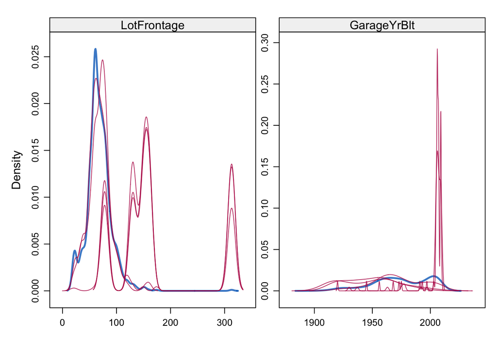

```r
densityplot(tempData)
```

## Limpeza de daos

separamos os dados em dois datavframes então: um com dados numéricos e outro com dados categóricos. Depois realizamos o encoding das variáveis categóricas afim de tornar possível a compressão delas pelo algoritmo.

```r
num.train.data <- select_if(train.data, is.numeric)
cat.train.data <- select_if(train.data, function(x){!is.numeric(x)})

# Factor categorical data
col.names <- colnames(cat.train.data)
cat.train.data <- cat.train.data %>% mutate_at(col.names, factor)
```

## EDA - Análise Exploratória de Dados

Para facilitar a exploração de dados, juntamos todos os dados “limpos” num único dataframe novamente.

```r
train.data <- cbind(num.train.data, cat.train.data)
```

Analisando a distribuição dos tipos de SalePrice, notação que temos um viés para o Mid Price.

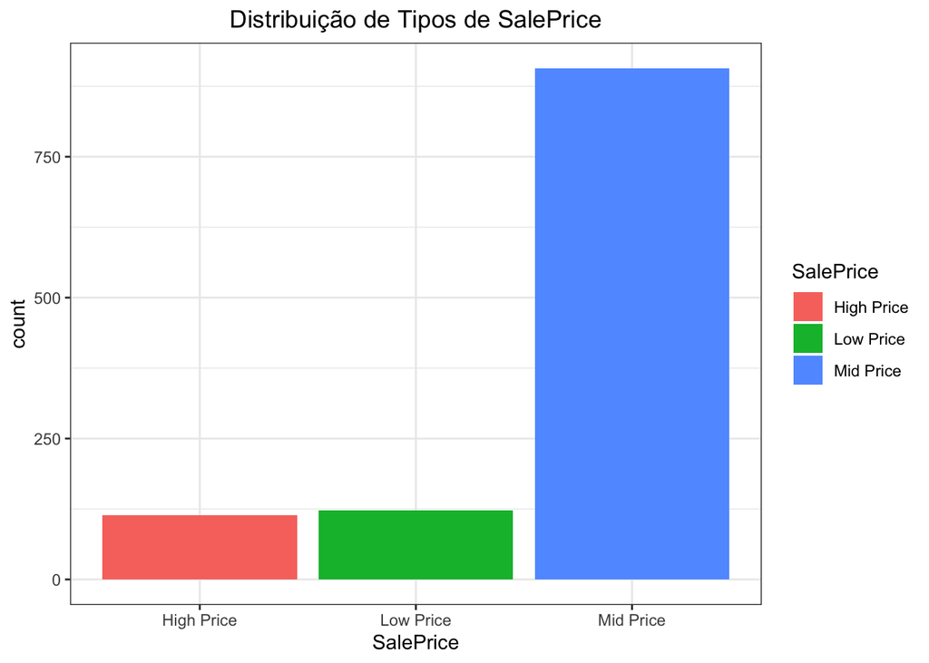

```r
pl <- ggplot(cat.train.data, aes(x = SalePrice)) + geom_bar(aes(fill = SalePrice)) + theme(plot.title = element_text(hjust = 0.5))
print(pl + ggtitle('Distribuição de Tipos de SalePrice'))
```

## Treinamento do modelo

```r
model <- randomForest(SalePrice ~., train.data)
```

Como modelo preditor vamos usar uma floresta aleatória. O modelo de classificar os dados em uma das 3 classes alvo: High, Low ou Mid Price.

Como o junto de teste também tem muitos dados faltantes vamos realizar a mesma estratégia de imputação de dados para o conjunto de teste também.

```r
test.data <- read.csv('test.csv')

test.data <- test.data %>% select(-PoolQC, - MiscFeature, - Alley, -Fence, -FireplaceQu)

# Performe same inputation stategy for test data
tempData <- mice(test.data,m=5,maxit=50,meth='pmm',seed=7)
test.data <- complete(tempData,3)
```

É importante observar que vamos precisar fazer o encoding das variáveis categóricas do conjunto de teste assim como fizemos no conjunto de treino.

```r
num.test.data <- select_if(test.data, is.numeric)
cat.test.data <- select_if(test.data, function(x){!is.numeric(x)})

# Factor categorical data
col.names <- colnames(cat.test.data)
for (col in col.names) {
  levels(cat.test.data[col]) <- levels(cat.train.data[col])
}

# Join test data again
test.data <- cbind(num.test.data, cat.test.data)

# Make predictions
# predictions <- predict(model, test.data, type = "class")
```

```r
# confusionMatrix(predictions, testing$classe)
```

# Referências

### Métodos de imputação de dados com R

- https://datascienceplus.com/imputing-missing-data-with-r-mice-packag/
- https://towardsdatascience.com/smart-handling-of-missing-data-in-r-6425f8a559f2